# STATS 506 — Homework 2

Author

Zixuan Wei

GitHub repository: IvyWeiii/DS506

# Problem 1: Random Walk with Momentum

## (a) Simulation Function and Input Validation

```r
#' Simulate a two-dimensional random walk with momentum.
#'
#' @param n A single finite positive integer giving the number of steps.
#' @param p A single finite number between 0 and 1 giving the probability
#'   of preserving the previous direction.
#' @return A named numeric vector containing the final x and y coordinates.
momentum_walk <- function(n, p) {
  # Validate the number of steps.
  if (!is.numeric(n) || is.complex(n) || length(n) != 1L) {
    stop("n must be a single positive integer.")
  }
  if (is.na(n) || !is.finite(n) || n < 1 || n != floor(n)) {
    stop("n must be a single finite positive integer.")
  }

  # Validate the momentum probability.
  if (!is.numeric(p) || is.complex(p) || length(p) != 1L) {
    stop("p must be a single number between 0 and 1.")
  }
  if (is.na(p) || !is.finite(p) || p < 0 || p > 1) {
    stop("p must be a single finite number between 0 and 1.")
  }

  # Each row represents one possible displacement.
  directions <- rbind(
    right = c(1, 0),
    left = c(-1, 0),
    up = c(0, 1),
    down = c(0, -1)
  )
  colnames(directions) <- c("x", "y")

  # Choose the first direction uniformly.
  direction_id <- sample.int(4, size = 1)
  position <- directions[direction_id, ]

  # Simulate the remaining steps.
  if (n > 1) {
    for (step in seq_len(n - 1)) {
      if (runif(1) >= p) {
        direction_id <- sample.int(4, size = 1)
      }
      position <- position + directions[direction_id, ]
    }
  }

  return(position)
}

# Demonstrate a ten-step walk.
momentum_walk(10, 0.6)
```

```
x y
0 0
```

```r
# Check a one-step walk and full momentum.
momentum_walk(1, 0.6)
```

```
x y
1 0
```

```r
momentum_walk(10, 1)
```

```
 x  y
 0 10
```

```r
# Demonstrate invalid-input handling without stopping the document.
tryCatch(momentum_walk(0, 0.6), error = conditionMessage)
```

```
[1] "n must be a single finite positive integer."
```

```r
tryCatch(momentum_walk(10, 1.2), error = conditionMessage)
```

```
[1] "p must be a single finite number between 0 and 1."
```

## (b) Loop and Apply Implementations

```r
# Reuse the for-loop implementation from part (a).
# It has the same inputs, validation, and return value.
momentum_walk1 <- momentum_walk

#' Simulate a two-dimensional momentum walk using vapply().
#'
#' @param n A single finite positive integer specifying the step count.
#' @param p A single finite probability between 0 and 1.
#' @return A named numeric vector containing the final x and y coordinates.
momentum_walk2 <- function(n, p) {
  # Validate the number of steps.
  if (!is.numeric(n) || is.complex(n) || length(n) != 1L) {
    stop("n must be a single positive integer.")
  }
  if (is.na(n) || !is.finite(n) || n < 1 || n != floor(n)) {
    stop("n must be a single finite positive integer.")
  }

  # Validate the momentum probability.
  if (!is.numeric(p) || is.complex(p) || length(p) != 1L) {
    stop("p must be a single number between 0 and 1.")
  }
  if (is.na(p) || !is.finite(p) || p < 0 || p > 1) {
    stop("p must be a single finite number between 0 and 1.")
  }

  # Each row represents one possible unit displacement.
  directions <- rbind(
    right = c(1, 0),
    left  = c(-1, 0),
    up    = c(0, 1),
    down  = c(0, -1)
  )
  colnames(directions) <- c("x", "y")

  # Choose the first direction uniformly and take the first step.
  direction_id <- sample.int(4, size = 1)
  position <- directions[direction_id, ]

  if (n > 1) {
    # Generate subsequent displacements in order.
    remaining_steps <- vapply(
      seq_len(n - 1),
      function(step) {
        if (runif(1) >= p) {
          # Update the direction stored in the enclosing function.
          direction_id <<- sample.int(4, size = 1)
        }
        directions[direction_id, ]
      },
      FUN.VALUE = numeric(2)
    )

    # Columns represent steps; rows represent x and y displacements.
    position <- position + rowSums(remaining_steps)
  }

  return(position)
}

# Demonstrate both implementations using the requested inputs.
momentum_walk1(10, 0.6)
```

```
 x  y
-2  0
```

```r
momentum_walk2(10, 0.6)
```

```
 x  y
 3 -3
```

```r
momentum_walk1(1000, 0.6)
```

```
 x  y
68 14
```

```r
momentum_walk2(1000, 0.6)
```

```
 x  y
13 25
```

The loop implementation, `momentum_walk1()`, reuses the function from part (a). It selects the first direction uniformly, then uses a for loop to choose each subsequent direction and update the position.

The apply implementation, `momentum_walk2()`, uses `vapply()` to generate the remaining displacements sequentially. The direction is stored in the enclosing function and updated using `<<-`, allowing each step to depend on the previous direction. Each displacement becomes a column of a matrix, and `rowSums()` adds these displacements to the first-step position.

In both implementations, each subsequent step preserves the previous direction with probability p. Otherwise, it samples uniformly from all four directions, including the previous direction. Both functions return the final x and y coordinates. The four calls use successive random draws, so their results need not match.

## (c) Reproducibility

```r
# Repeat a ten-step walk after resetting the same seed.
set.seed(506)
walk10_first <- momentum_walk1(10, 0.6)

set.seed(506)
walk10_repeat <- momentum_walk1(10, 0.6)

rbind(
  First = walk10_first,
  Repeat = walk10_repeat
)
```

```
        x y
First  -2 0
Repeat -2 0
```

```r
identical(walk10_first, walk10_repeat)
```

```
[1] TRUE
```

```r
# Repeat a thousand-step walk after resetting the same seed.
set.seed(506)
walk1000_first <- momentum_walk1(1000, 0.6)

set.seed(506)
walk1000_repeat <- momentum_walk1(1000, 0.6)

rbind(
  First = walk1000_first,
  Repeat = walk1000_repeat
)
```

```
         x   y
First  -14 -30
Repeat -14 -30
```

```r
identical(walk1000_first, walk1000_repeat)
```

```
[1] TRUE
```

I used the loop implementation, `momentum_walk1()`, and reset the random seed to 506 before each repeated simulation. For each step count, the two runs produce identical final coordinates, as verified by `identical()` returning TRUE.

R uses a pseudorandom-number generator. Resetting the same seed restores the same initial generator state. With the same inputs, implementation, and random-number generator settings, the function therefore makes the same random choices and produces the same result.

## (d) Does Momentum Matter?

```r
# Make the comparison reproducible.
set.seed(506)

# Simulate one 1,000-step walk for each momentum probability.
p_values <- c(0, 0.5, 0.9)

endpoints <- vapply(
  p_values,
  function(p) momentum_walk1(1000, p),
  FUN.VALUE = numeric(2)
)

# Compute the Euclidean distance from the origin for each endpoint.
distances <- sqrt(colSums(endpoints^2))

comparison <- data.frame(
  p = p_values,
  x = endpoints[1, ],
  y = endpoints[2, ],
  distance = distances
)

knitr::kable(
  comparison,
  digits = 3,
  col.names = c("Momentum (p)", "Final x", "Final y", "Distance")
)
```

| Momentum (p) | Final x | Final y | Distance |
| --- | --- | --- | --- |
| 0.0 | 3 | -23 | 23.195 |
| 0.5 | -62 | 6 | 62.290 |
| 0.9 | -25 | -155 | 157.003 |

```r
# Describe the observed pattern without assuming it is increasing.
trend_description <- if (all(diff(distances) > 0)) {
  "the distance increased as momentum increased"
} else if (all(diff(distances) < 0)) {
  "the distance decreased as momentum increased"
} else {
  "the distance did not follow a strictly increasing or decreasing pattern"
}
```

I simulated one 1,000-step walk for each momentum probability, $p = 0$, $p = 0.5$, and $p = 0.9$. For each final position $(x, y)$, I calculated the Euclidean distance from the origin:

$$d = \sqrt{x^2 + y^2}.$$

The distances were 23.195, 62.290, and 157.003 for $p = 0$, $p = 0.5$, and $p = 0.9$, respectively. In these simulations, the distance increased as momentum increased.

Higher momentum makes consecutive steps more likely to follow the same direction. In particular, the probability of repeating the previous direction is $p + (1-p)/4$, because a uniform redraw can also select that direction. Greater persistence tends to produce longer stretches of movement in one direction, suggesting a greater distance from the origin on average.

However, this comparison uses only one simulated walk for each value of p. Random variation can affect the observed ordering, so these three results alone cannot establish how the average distance changes with momentum. Repeated simulations are needed to assess that pattern.

## (e) Monte Carlo Simulation

```r
# Set the seed once for the entire Monte Carlo experiment.
set.seed(506)

p_grid <- c(0, 0.25, 0.5, 0.75, 0.9)
n_walks <- 1000
n_steps <- 1000

# Simulate independent walks and calculate their final distances.
distance_samples <- lapply(p_grid, function(p) {
  replicate(n_walks, {
    endpoint <- momentum_walk1(n_steps, p)
    sqrt(sum(endpoint^2))
  })
})

# Calculate the mean final distance for each momentum probability.
mean_distances <- vapply(
  distance_samples,
  mean,
  FUN.VALUE = numeric(1)
)

mc_results <- data.frame(
  p = p_grid,
  mean_distance = mean_distances
)

knitr::kable(mc_results, digits = 3)
```

| p | mean_distance |
| --- | --- |
| 0.00 | 27.754 |
| 0.25 | 36.243 |
| 0.50 | 48.418 |
| 0.75 | 75.695 |
| 0.90 | 122.895 |

```r
# Summarize the observed pattern.
mc_trend <- if (all(diff(mean_distances) > 0)) {
  "The estimated mean final distance increased at every successive value of p."
} else {
  paste(
    "The estimated mean final distances did not increase",
    "at every successive value of p."
  )
}
```

For each momentum probability, I simulated 1,000 independent walks, each containing 1,000 steps. I calculated the final distance of each walk as $D_i = \sqrt{x_i^2 + y_i^2}$ and estimated the mean distance by

$$\widehat{D}_p = \frac{1}{1000}\sum_{i=1}^{1000} D_i.$$

The outer `lapply()` processes the five momentum probabilities. For each probability, `replicate()` generates 1,000 walks and records their final distances. Finally, `vapply()` calculates the mean of each set of distances.

The estimated mean final distance increased at every successive value of p. The estimated mean distance was 27.754 at $p = 0$ and 122.895 at $p = 0.9$.

Higher momentum makes consecutive steps more likely to continue in the same direction. This reduces cancellation between steps and tends to move the walker farther from the origin. Averaging over 1,000 walks provides a more stable comparison than the single walks in part (d), although the estimates still contain Monte Carlo variation.

I set the seed once before the experiment to make the results reproducible. I did not reset it inside `replicate()`, which would repeat the same random sequence rather than generate new walks.

## (f) Computational Performance

```r
# Compare the two implementations using repeated timing measurements.
library(microbenchmark)

set.seed(506)

benchmark_small <- microbenchmark(
  loop = momentum_walk1(1000, 0.6),
  apply = momentum_walk2(1000, 0.6),
  times = 20L
)
benchmark_large <- microbenchmark(
  loop = momentum_walk1(100000, 0.6),
  apply = momentum_walk2(100000, 0.6),
  times = 20L
)

# Extract median execution times in milliseconds.
small_summary <- summary(benchmark_small, unit = "ms")
large_summary <- summary(benchmark_large, unit = "ms")

timing_results <- data.frame(
  n = c(1000, 100000),
  loop_median_ms = c(
    small_summary$median[small_summary$expr == "loop"],
    large_summary$median[large_summary$expr == "loop"]
  ),
  apply_median_ms = c(
    small_summary$median[small_summary$expr == "apply"],
    large_summary$median[large_summary$expr == "apply"]
  )
)

# Compare absolute timing gaps and relative execution times.
timing_results$absolute_gap_ms <- abs(
  timing_results$apply_median_ms -
    timing_results$loop_median_ms
)

timing_results$apply_to_loop_ratio <-
  timing_results$apply_median_ms / timing_results$loop_median_ms

knitr::kable(timing_results, digits = 3)
```

| n | loop_median_ms | apply_median_ms | absolute_gap_ms | apply_to_loop_ratio |
| --- | --- | --- | --- | --- |
| 1e+03 | 1.444 | 1.702 | 0.258 | 1.179 |
| 1e+05 | 153.634 | 179.427 | 25.793 | 1.168 |

```r
# Identify the faster implementation at each input size.
faster_version <- ifelse(
  timing_results$loop_median_ms < timing_results$apply_median_ms,
  "the loop implementation",
  ifelse(
    timing_results$loop_median_ms > timing_results$apply_median_ms,
    "the apply implementation",
    "neither implementation (their median times were equal)"
  )
)

gap_comparison <- if (
  timing_results$absolute_gap_ms[2] >
    timing_results$absolute_gap_ms[1]
) {
  "The absolute difference in median execution time was larger for the larger input."
} else if (
  timing_results$absolute_gap_ms[2] <
    timing_results$absolute_gap_ms[1]
) {
  "The absolute difference in median execution time was smaller for the larger input."
} else {
  "The absolute difference in median execution time was the same for both input sizes."
}
```

I benchmarked each implementation 20 times and compared median execution times in milliseconds. At $n = 1000$, the faster version was the loop implementation; at $n = 100000$, it was the loop implementation.

The absolute difference in median execution time was larger for the larger input. The absolute gap changed from 0.258 ms to 25.793 ms.

The loop updates the position directly, while the apply version calls an inner function for each step, stores the displacements in a matrix, and sums them afterward. These function-call and memory-allocation costs can affect performance, so using an apply function is not necessarily faster. Exact timings depend on the computer and may vary between runs.

# Problem 2: Campus Bus Arrivals

```r
# Simulate 10,000 days without loops.
set.seed(506)
n_days <- 10000

# Each matrix row represents one day; columns represent hours.
early_morning <- rowSums(
  matrix(rpois(n_days * 3, lambda = 4), nrow = n_days)
)

morning_peak <- rnorm(n_days, mean = 45, sd = sqrt(16))

midday <- rowSums(
  matrix(rpois(n_days * 6, lambda = 15), nrow = n_days)
)

afternoon_peak <- rnorm(n_days, mean = 55, sd = sqrt(25))

evening <- rowSums(
  matrix(rpois(n_days * 6, lambda = 9), nrow = n_days)
)

# Combine all hourly passenger counts for each day.
daily_total <- early_morning + morning_peak + midday +
  afternoon_peak + evening

estimated_mean <- mean(daily_total)

# Check the simulation against the theoretical expectation.
theoretical_mean <- 3 * 4 + 45 + 6 * 15 + 55 + 6 * 9

results <- data.frame(
  simulated_days = n_days,
  estimated_daily_mean = estimated_mean,
  theoretical_daily_mean = theoretical_mean
)

knitr::kable(results, digits = 3)
```

| simulated_days | estimated_daily_mean | theoretical_daily_mean |
| --- | --- | --- |
| 10000 | 256.178 | 256 |

The estimated average daily passenger total is **256.178 passengers**. I generated independent hourly values using vectorized `rpois()` and `rnorm()` calls. Each matrix row represents one day, and `rowSums()` combines the hours within each Poisson period. No loops were used.

The theoretical expected daily total is

$$E[T] = 3(4) + 45 + 6(15) + 55 + 6(9) = 256.$$

The simulation estimate should be close to 256, with any difference due to Monte Carlo variation. I used standard deviations of 4 and 5 for the two Normal distributions and retained their simulated values without rounding to follow the specified model.

# Problem 3: Linear Regression

## (a) Data Preparation and De-identification

```r
# Import the dataset provided in the assignment.
youtube <- read.csv(
  "https://raw.githubusercontent.com/rfordatascience/tidytuesday/master/data/2021/2021-03-02/youtube.csv",
  stringsAsFactors = FALSE
)

# Remove identifying information and video-specific metadata.
identifying_vars <- c(
  "brand",
  "superbowl_ads_dot_com_url",
  "youtube_url",
  "id",
  "etag",
  "published_at",
  "title",
  "description",
  "thumbnail",
  "channel_title"
)

youtube_clean <- youtube[
  , !(names(youtube) %in% identifying_vars),
  drop = FALSE
]

# Report dimensions before and after removing columns.
dimension_summary <- data.frame(
  dataset = c("Original", "After removing identifying variables"),
  observations = c(nrow(youtube), nrow(youtube_clean)),
  variables = c(ncol(youtube), ncol(youtube_clean))
)

knitr::kable(dimension_summary, row.names = FALSE)
```

| dataset | observations | variables |
| --- | --- | --- |
| Original | 247 | 25 |
| After removing identifying variables | 247 | 15 |

```r
# Display the retained variables.
names(youtube_clean)
```

```
 [1] "year"                 "funny"                "show_product_quickly"
 [4] "patriotic"            "celebrity"            "danger"
 [7] "animals"              "use_sex"              "kind"
[10] "view_count"           "like_count"           "dislike_count"
[13] "favorite_count"       "comment_count"        "category_id"
```

I removed the brand, URLs, video ID, API tag, publication timestamp, title, description, thumbnail, and channel title because they identify or help trace a particular commercial.

The resulting dataset contains **247 observations and 15 variables**. No rows were removed. I retained year for the subsequent regression models, along with the seven advertising characteristics and five engagement measures. I also retained `kind` and `category_id`, which describe the resource type and video category rather than identify a specific commercial.

## (b) Exploring Potential Outcomes

```r
# Summarize the five engagement variables.
engagement_vars <- c(
  "view_count", "like_count", "dislike_count",
  "favorite_count", "comment_count"
)

distribution_summary <- do.call(
  rbind,
  lapply(engagement_vars, function(variable) {
    x <- youtube_clean[[variable]]

    data.frame(
      variable = variable,
      missing = sum(is.na(x)),
      zeros = sum(x == 0, na.rm = TRUE),
      median = median(x, na.rm = TRUE),
      mean = mean(x, na.rm = TRUE),
      maximum = max(x, na.rm = TRUE)
    )
  })
)

knitr::kable(distribution_summary, digits = 2, row.names = FALSE)
```

| variable | missing | zeros | median | mean | maximum |
| --- | --- | --- | --- | --- | --- |
| view_count | 16 | 0 | 41379 | 1407556.46 | 176373378 |
| like_count | 22 | 9 | 130 | 4146.03 | 275362 |
| dislike_count | 22 | 47 | 7 | 833.54 | 92990 |
| favorite_count | 16 | 231 | 0 | 0.00 | 0 |
| comment_count | 25 | 41 | 10 | 188.64 | 9190 |

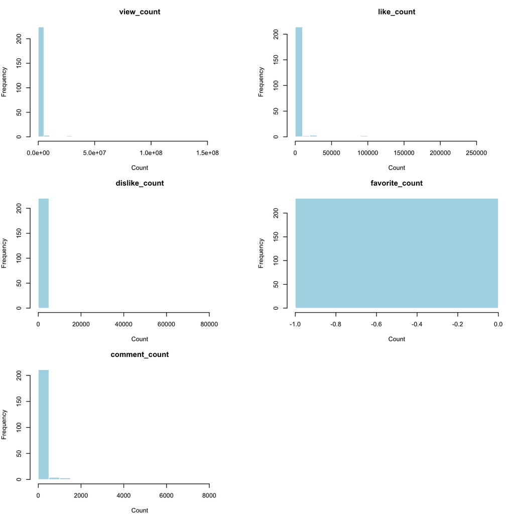

```r
# Examine the distributions on their original scales.
old_par <- par(mfrow = c(3, 2), mar = c(4, 4, 3, 1))

for (variable in engagement_vars) {
  x <- youtube_clean[[variable]]
  hist(
    x[!is.na(x)],
    breaks = 30,
    main = variable,
    xlab = "Count",
    col = "lightblue",
    border = "white"
  )
}

par(old_par)
```

```r
# Transform the four nonconstant outcomes.
outcome_vars <- c(
  "view_count", "like_count", "dislike_count", "comment_count"
)

log_outcome_vars <- paste0("log_", outcome_vars)

youtube_clean[log_outcome_vars] <- lapply(
  youtube_clean[outcome_vars],
  log1p
)
```

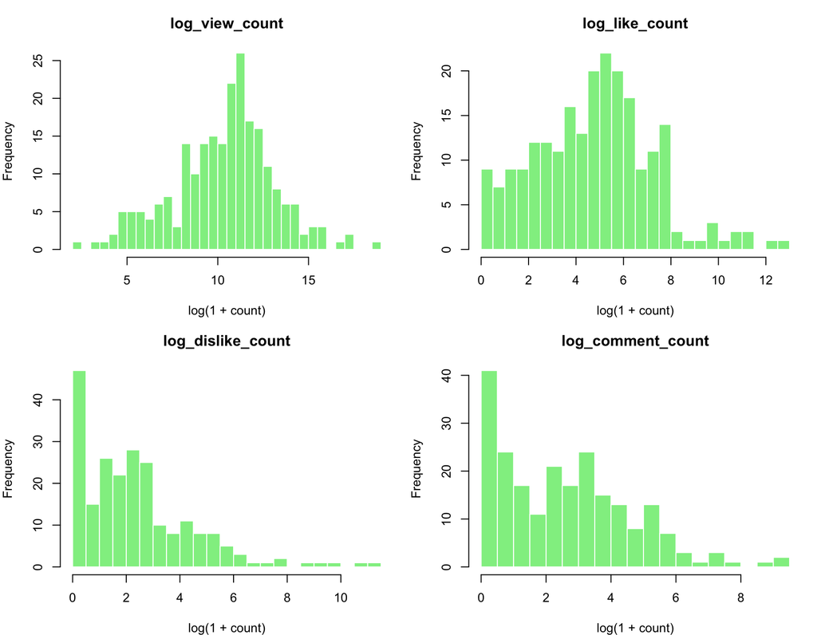

```r
# Inspect the transformed distributions.
old_par <- par(mfrow = c(2, 2), mar = c(4, 4, 3, 1))

for (variable in log_outcome_vars) {
  x <- youtube_clean[[variable]]
  hist(
    x[!is.na(x)],
    breaks = 25,
    main = variable,
    xlab = "log(1 + count)",
    col = "lightgreen",
    border = "white"
  )
}
```

```r
par(old_par)
```

| Outcome | Decision | Justification |
| --- | --- | --- |
| View count | Category 2: transform | Strong right skew and very large observations; a log transformation compresses the upper tail. |
| Like count | Category 2: transform | Strong right skew with some zeros; `log1p()` accommodates zeros. |
| Dislike count | Category 2: transform | Many zeros and a long right tail; `log1p()` reduces the scale of extreme values. |
| Favorite count | Category 3: exclude | All 231 observed values are zero, so there is no outcome variation to model. |
| Comment count | Category 2: transform | Zeros and a long right tail; `log1p()` reduces skew while retaining zero counts. |

I used the transformation $\log(1+y)$ for views, likes, dislikes, and comments and will use these transformed outcomes in the remaining analyses. Missing values remain missing and are not replaced with zeros.

Linear regression does not require the outcome itself to be normally distributed. These transformations are preliminary choices intended to reduce skew and the influence of extreme outcome values; residual diagnostics are still needed to assess the fitted models.

## (c) Fitting Linear Regression Models

```r
# Define the seven binary commercial characteristics.
traits <- c(
  "funny", "show_product_quickly", "patriotic",
  "celebrity", "danger", "animals", "use_sex"
)

# Use the transformed outcomes created in part (b).
outcomes <- c(
  "log_view_count", "log_like_count",
  "log_dislike_count", "log_comment_count"
)

# Code each characteristic as 0 (absent) or 1 (present).
regression_data <- youtube_clean
regression_data[traits] <- lapply(
  regression_data[traits],
  as.integer
)

# Fit a separate year-adjusted model for each outcome-trait pair.
regression_results <- do.call(
  rbind,
  lapply(outcomes, function(outcome) {
    do.call(
      rbind,
      lapply(traits, function(trait) {
        model_formula <- reformulate(
          c(trait, "year"),
          response = outcome
        )

        fit <- lm(
          model_formula,
          data = regression_data,
          na.action = na.omit
        )

        coefficient_table <- coef(summary(fit))

        data.frame(
          outcome = outcome,
          characteristic = trait,
          n = nobs(fit),
          estimate = coefficient_table[trait, "Estimate"],
          p_value = coefficient_table[trait, "Pr(>|t|)"]
        )
      })
    )
  })
)

regression_results$significant <-
  regression_results$p_value < 0.05

knitr::kable(
  regression_results,
  digits = 4,
  row.names = FALSE
)
```

| outcome | characteristic | n | estimate | p_value | significant |
| --- | --- | --- | --- | --- | --- |
| log_view_count | funny | 231 | 0.5298 | 0.2051 | FALSE |
| log_view_count | show_product_quickly | 231 | 0.2090 | 0.6007 | FALSE |
| log_view_count | patriotic | 231 | 0.1369 | 0.7839 | FALSE |
| log_view_count | celebrity | 231 | -0.0190 | 0.9629 | FALSE |
| log_view_count | danger | 231 | 0.6668 | 0.0941 | FALSE |
| log_view_count | animals | 231 | -0.1733 | 0.6467 | FALSE |
| log_view_count | use_sex | 231 | -0.2963 | 0.4905 | FALSE |
| log_like_count | funny | 225 | 0.3602 | 0.3401 | FALSE |
| log_like_count | show_product_quickly | 225 | 0.1683 | 0.6405 | FALSE |
| log_like_count | patriotic | 225 | 0.4931 | 0.2897 | FALSE |
| log_like_count | celebrity | 225 | 0.2630 | 0.4779 | FALSE |
| log_like_count | danger | 225 | 0.6253 | 0.0803 | FALSE |
| log_like_count | animals | 225 | 0.0246 | 0.9428 | FALSE |
| log_like_count | use_sex | 225 | -0.3250 | 0.4001 | FALSE |
| log_dislike_count | funny | 225 | 0.0415 | 0.8958 | FALSE |
| log_dislike_count | show_product_quickly | 225 | 0.2429 | 0.4210 | FALSE |
| log_dislike_count | patriotic | 225 | 0.6697 | 0.0856 | FALSE |
| log_dislike_count | celebrity | 225 | -0.2833 | 0.3616 | FALSE |
| log_dislike_count | danger | 225 | 0.1851 | 0.5379 | FALSE |
| log_dislike_count | animals | 225 | -0.0738 | 0.7974 | FALSE |
| log_dislike_count | use_sex | 225 | -0.3889 | 0.2293 | FALSE |
| log_comment_count | funny | 222 | 0.0475 | 0.8793 | FALSE |
| log_comment_count | show_product_quickly | 222 | 0.3460 | 0.2469 | FALSE |
| log_comment_count | patriotic | 222 | 0.5148 | 0.1685 | FALSE |
| log_comment_count | celebrity | 222 | 0.2281 | 0.4556 | FALSE |
| log_comment_count | danger | 222 | 0.1064 | 0.7210 | FALSE |
| log_comment_count | animals | 222 | -0.1918 | 0.4991 | FALSE |
| log_comment_count | use_sex | 222 | -0.3494 | 0.2735 | FALSE |

```r
# Find the largest positive coefficient among the view-count models.
view_results <- subset(
  regression_results,
  outcome == "log_view_count"
)

largest_positive_view <- view_results[
  which.max(view_results$estimate),
  c("characteristic", "estimate", "p_value")
]

knitr::kable(
  largest_positive_view,
  digits = 4,
  row.names = FALSE
)
```

| characteristic | estimate | p_value |
| --- | --- | --- |
| danger | 0.6668 | 0.0941 |

For each transformed outcome, I fitted seven separate models of the form

$$\log(1 + Y_i)
= \beta_0 + \beta_1 X_i + \beta_2 \mathrm{year}_i + \varepsilon_i,$$

where $X_i$ indicates whether the commercial has the selected characteristic. Each model includes one characteristic and year, rather than all seven characteristics together. Observations missing variables required by a model were omitted.

None of the seven characteristics had a statistically significant association with any of the four transformed outcomes at $\alpha = 0.05$. Therefore, there are no significant positive or negative associations to report. This does not establish that the associations are zero.

For transformed view counts, **danger** had the largest positive estimated coefficient: **0.6668**, with $p = 0.0941$. This coefficient describes an adjusted difference on the $\log(1+\text{views})$ scale and was not statistically significant.

## (d) Regression Coefficients Using Matrix Algebra

```r
# Select the characteristic with the smallest view-count p-value.
view_models <- subset(
  regression_results,
  outcome == "log_view_count"
)

selected_trait <- view_models$characteristic[
  which.min(view_models$p_value)
]

selected_trait
```

```
[1] "danger"
```

```r
# Use the same complete observations for both estimation methods.
required_vars <- c("log_view_count", selected_trait, "year")

model_data <- regression_data[
  complete.cases(regression_data[required_vars]),
  required_vars,
  drop = FALSE
]

# Construct the response vector and design matrix explicitly.
y <- model_data$log_view_count

X <- cbind(
  intercept = rep(1, nrow(model_data)),
  characteristic = model_data[[selected_trait]],
  year = model_data$year
)

colnames(X) <- c("(Intercept)", selected_trait, "year")

# Estimate coefficients without using lm().
# Solve (X'X) beta = X'y.
beta_matrix <- drop(
  solve(crossprod(X), crossprod(X, y))
)

# Fit the identical model using lm() for comparison.
model_formula <- reformulate(
  c(selected_trait, "year"),
  response = "log_view_count"
)

fit_lm <- lm(model_formula, data = model_data)
beta_lm <- coef(fit_lm)[colnames(X)]

coefficient_comparison <- data.frame(
  term = colnames(X),
  matrix_estimate = unname(beta_matrix),
  lm_estimate = unname(beta_lm),
  absolute_difference = unname(abs(beta_matrix - beta_lm))
)

knitr::kable(
  coefficient_comparison,
  digits = 10,
  row.names = FALSE
)
```

| term | matrix_estimate | lm_estimate | absolute_difference |
| --- | --- | --- | --- |
| (Intercept) | -31.39149243 | -31.39149243 | 4e-10 |
| danger | 0.66678076 | 0.66678076 | 0e+00 |
| year | 0.02065641 | 0.02065641 | 0e+00 |

```r
# Verify agreement within a numerical tolerance.
max_difference <- max(abs(beta_matrix - beta_lm))
coefficients_agree <- max_difference < 1e-8

coefficients_agree
```

```
[1] TRUE
```

I selected **danger** because it had the smallest p-value among the seven year-adjusted view-count models in part (c). The response is $\log(1+\text{view count})$, as chosen in part (b).

The design matrix contains an intercept, the selected binary characteristic, and year. I calculated

$$\widehat{\boldsymbol{\beta}}
= (X^\mathsf{T}X)^{-1}X^\mathsf{T}y$$

using `crossprod()` and `solve()`. The two-argument form of `solve()` solves the normal equations without explicitly forming the inverse.

Using the same **231 observations**, the matrix estimates and `lm()` estimates agree within numerical precision. Their maximum absolute difference is **4.25e-10**, below the tolerance of $10^{-8}$.

# Sources and AI Assistance

- OpenAI ChatGPT: Assisted with interpreting the assignment requirements, developing and debugging portions of the R and Quarto workflow, and reviewing the final output. I reviewed and verified the code, results, and explanations before submission.